# PEC 4 ML Diego_VZ

Predicción de la variedad de uva a partir del análisis químico del vino

Autor: Diego Vázquez Zambrano

Fecha: 23/06/2023

**Table of contents**

1. Carga de datos
2. División de datos en conjuntos de entrenamiento y prueba
3. Estadísticas descriptivas y visualización de datos
4. Clasificación con k-NN (k-Nearest Neighbors)
5. Clasificación con Naive Bayes
6. Definición de diferentes arquitecturas de la red neuronal
7. Clasificación con SVM (Support Vector Machines)
8. Clasificación con Árbol de Clasificación
9. Clasificación con Random Forest
10. Sección de discusión de resultados obtenidos
1. Carga de datos

```python
import pandas as pd
data = pd.read_csv('D:\wine.data', header=None)
print(data)

column_names = ['Clase', 'Alcohol', 'Malic acid', 'Ash', 'Alcalinity of ash', 'Magnesium', 'Total phenols',
                'Flavanoids', 'Nonflavanoid phenols', 'Proanthocyanins', 'Color intensity', 'Hue',
                'OD280/OD315 of diluted wines', 'Proline']
data.columns = column_names
print(data.head())
```

```
     0      1     2     3     4    5     6     7     8     9      10    11  \
0     1  14.23  1.71  2.43  15.6  127  2.80  3.06  0.28  2.29   5.64  1.04
1     1  13.20  1.78  2.14  11.2  100  2.65  2.76  0.26  1.28   4.38  1.05
2     1  13.16  2.36  2.67  18.6  101  2.80  3.24  0.30  2.81   5.68  1.03
3     1  14.37  1.95  2.50  16.8  113  3.85  3.49  0.24  2.18   7.80  0.86
4     1  13.24  2.59  2.87  21.0  118  2.80  2.69  0.39  1.82   4.32  1.04
..   ..    ...   ...   ...   ...  ...   ...   ...   ...   ...    ...   ...
173   3  13.71  5.65  2.45  20.5   95  1.68  0.61  0.52  1.06   7.70  0.64
174   3  13.40  3.91  2.48  23.0  102  1.80  0.75  0.43  1.41   7.30  0.70
175   3  13.27  4.28  2.26  20.0  120  1.59  0.69  0.43  1.35  10.20  0.59
176   3  13.17  2.59  2.37  20.0  120  1.65  0.68  0.53  1.46   9.30  0.60
177   3  14.13  4.10  2.74  24.5   96  2.05  0.76  0.56  1.35   9.20  0.61

       12    13
0    3.92  1065
```

[output cut: 32 more lines]

2. División de datos en conjuntos de entrenamiento y prueba

```python
from sklearn.model_selection import train_test_split

# Dividir los datos en conjuntos de entrenamiento y prueba
X = data.drop('Clase', axis=1)  # Variables independientes
y = data['Clase']  # Variable objetivo

# División de datos con una proporción de 67% para entrenamiento y 33% para prueba
X_train, X_test, y_train, y_test = train_test_split(X, y, test_size=0.33, random_state=12345)

# Verificar la forma de los conjuntos de entrenamiento y prueba
print("Forma de X_train:", X_train.shape)
print("Forma de X_test:", X_test.shape)
print("Forma de y_train:", y_train.shape)
print("Forma de y_test:", y_test.shape)
```

```
Forma de X_train: (119, 13)
Forma de X_test: (59, 13)
Forma de y_train: (119,)
Forma de y_test: (59,)
```

3. Estadísticas descriptivas y visualización de datos

```
Estadísticas descriptivas:
            Clase     Alcohol  Malic acid         Ash  Alcalinity of ash  \
count  178.000000  178.000000  178.000000  178.000000         178.000000
mean     1.938202   13.000618    2.336348    2.366517          19.494944
std      0.775035    0.811827    1.117146    0.274344           3.339564
min      1.000000   11.030000    0.740000    1.360000          10.600000
25%      1.000000   12.362500    1.602500    2.210000          17.200000
50%      2.000000   13.050000    1.865000    2.360000          19.500000
75%      3.000000   13.677500    3.082500    2.557500          21.500000
max      3.000000   14.830000    5.800000    3.230000          30.000000

        Magnesium  Total phenols  Flavanoids  Nonflavanoid phenols  \
count  178.000000     178.000000  178.000000            178.000000
mean    99.741573       2.295112    2.029270              0.361854
std     14.282484       0.625851    0.998859              0.124453
min     70.000000       0.980000    0.340000              0.130000
25%     88.000000       1.742500    1.205000              0.270000
50%     98.000000       2.355000    2.135000              0.340000
75%    107.000000       2.800000    2.875000              0.437500
max    162.000000       3.880000    5.080000              0.660000

       Proanthocyanins  Color intensity         Hue  \
count       178.000000       178.000000  178.000000
mean          1.590899         5.058090    0.957449
std           0.572359         2.318286    0.228572
min           0.410000         1.280000    0.480000
25%           1.250000         3.220000    0.782500
50%           1.555000         4.690000    0.965000
75%           1.950000         6.200000    1.120000
max           3.580000        13.000000    1.710000

       OD280/OD315 of diluted wines      Proline
count                    178.000000   178.000000
mean                       2.611685   746.893258
std                        0.709990   314.907474
min                        1.270000   278.000000
25%                        1.937500   500.500000
50%                        2.780000   673.500000
75%                        3.170000   985.000000
max                        4.000000  1680.000000
```

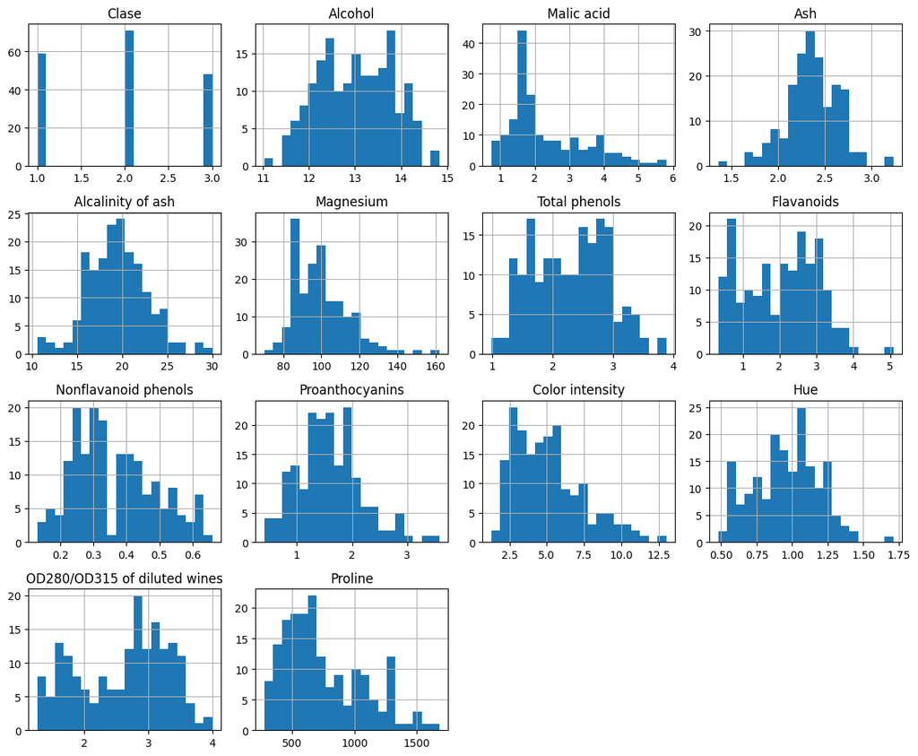

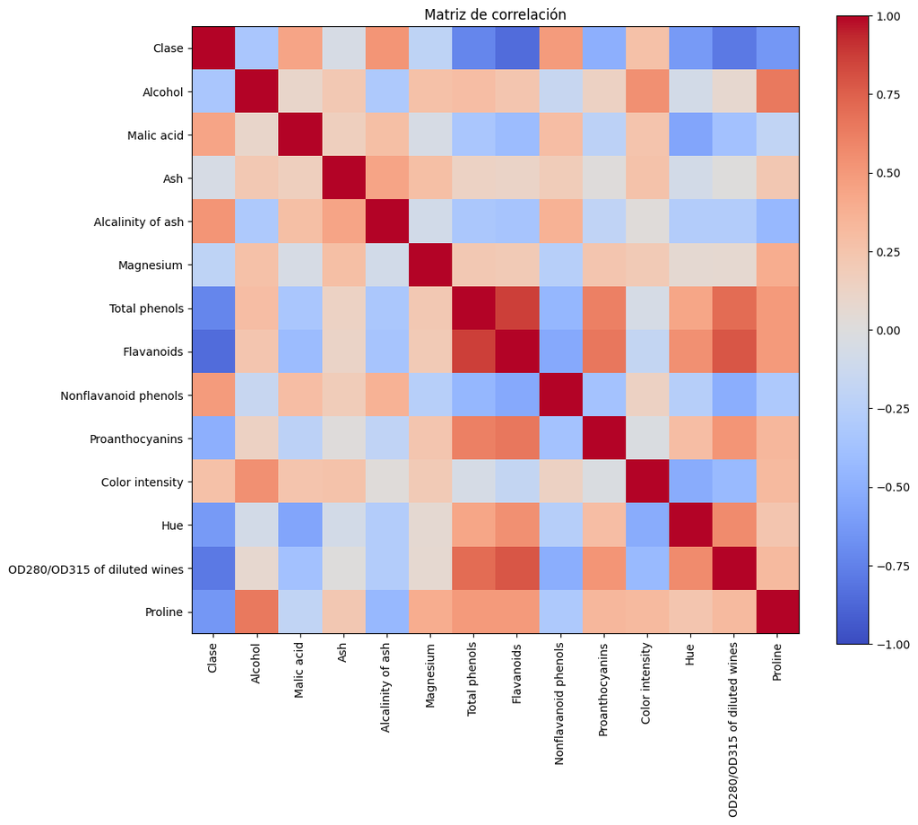

```python
import matplotlib.pyplot as plt

# Estadísticas descriptivas
print("Estadísticas descriptivas:")
print(data.describe())

# Gráficos de histograma para cada variable
data.hist(figsize=(12, 10), bins=20)
plt.tight_layout()
plt.show()

# Gráfico de matriz de correlación
corr_matrix = data.corr()
plt.figure(figsize=(12, 10))
plt.imshow(corr_matrix, cmap='coolwarm', vmin=-1, vmax=1)
plt.colorbar()
plt.xticks(range(len(corr_matrix)), corr_matrix.columns, rotation=90)
plt.yticks(range(len(corr_matrix)), corr_matrix.columns)
plt.title("Matriz de correlación")
plt.show()
```

4. Clasificación con k-NN (k-Nearest Neighbors)

```python
#Knn
from sklearn.neighbors import KNeighborsClassifier

# Probar diferentes valores para el número de vecinos k
k_values = [1, 3, 5, 7, 11]

for k in k_values:
    # Crear una instancia del modelo k-NN
    modelo = KNeighborsClassifier(n_neighbors=k)

    # Entrenar el modelo utilizando los datos de entrenamiento
    modelo.fit(X_train, y_train)

    # Realizar predicciones en el conjunto de prueba
    y_pred = modelo.predict(X_test)

    # Calcular la matriz de confusión y métricas adicionales
    cm = confusion_matrix(y_test, y_pred)
    report = classification_report(y_test, y_pred)

    # Imprimir resultados
    print(f"Resultados para k = {k}:")
    print("Matriz de confusión:")
    print(cm)
    print("Reporte de clasificación:")
    print(report)
    print("-----------------------------------")
```

```
Resultados para k = 1:
Matriz de confusión:
[[15  2  4]
 [ 1 17  4]
 [ 2  4 10]]
Reporte de clasificación:
              precision    recall  f1-score   support

           1       0.83      0.71      0.77        21
           2       0.74      0.77      0.76        22
           3       0.56      0.62      0.59        16

    accuracy                           0.71        59
   macro avg       0.71      0.70      0.70        59
weighted avg       0.72      0.71      0.72        59

-----------------------------------
Resultados para k = 3:
Matriz de confusión:
[[16  0  5]
 [ 3 13  6]
 [ 2  5  9]]
Reporte de clasificación:
              precision    recall  f1-score   support

           1       0.76      0.76      0.76        21
           2       0.72      0.59      0.65        22
           3       0.45      0.56      0.50        16

    accuracy                           0.64        59
   macro avg       0.64      0.64      0.64        59
weighted avg       0.66      0.64      0.65        59

-----------------------------------
Resultados para k = 5:
Matriz de confusión:
[[16  0  5]
 [ 2 13  7]
 [ 0  8  8]]
Reporte de clasificación:
```

[output cut: 30 more lines]

```
[[15  0  6]
 [ 2 14  6]
 [ 0  8  8]]
Reporte de clasificación:
              precision    recall  f1-score   support

           1       0.88      0.71      0.79        21
           2       0.64      0.64      0.64        22
           3       0.40      0.50      0.44        16

    accuracy                           0.63        59
   macro avg       0.64      0.62      0.62        59
weighted avg       0.66      0.63      0.64        59

-----------------------------------
```

k = 1: Este es el caso en el que se considera el vecino más cercano. El rendimiento parece ser el mejor en comparación con otros valores de k, con una precisión del 71%. Sin embargo, es importante tener en cuenta que k=1 puede ser sensible al ruido en los datos y podría resultar en sobreajuste.

k = 3: Con 3 vecinos, la precisión disminuye a 64%. Esto sugiere que al considerar más vecinos, el modelo se vuelve menos sensible a las fluctuaciones de los datos, pero también puede perder precisión si los vecinos no están bien clasificados.

k = 5: La precisión se mantiene similar a k=3, pero se puede observar que la precisión de la clase 1 ha aumentado, mientras que la de la clase 3 ha disminuido. Esto puede indicar que diferentes clases pueden beneficiarse de diferentes valores de k.

k = 7: La precisión permanece en el 63%, y al igual que antes, hay variaciones en las métricas de precisión, recall y f1-score entre las diferentes clases.

k = 11: De manera similar a k=7, la precisión sigue siendo de alrededor del 63%. A medida que k aumenta, el modelo tiende a ser más robusto frente al ruido, pero también puede suavizar demasiado las fronteras de decisión.

En general, estos resultados sugieren que un valor de k pequeño (como 1) puede dar el mejor rendimiento en este conjunto de datos en particular, pero hay que tener cuidado con el sobreajuste. Es importante validar la elección de k utilizando técnicas como la validación cruzada y, si es posible, evaluar el rendimiento en un conjunto de datos de prueba independiente. Además, es posible que desees explorar si la normalización de características o el uso de diferentes métricas de distancia puede mejorar el rendimiento del algoritmo k-NN.

5. Clasificiación con Naive Bayes

```python
#Naive Bayes
from sklearn.naive_bayes import GaussianNB

# Crear una instancia del modelo Naive Bayes
modelo = GaussianNB()

# Entrenar el modelo utilizando los datos de entrenamiento
modelo.fit(X_train, y_train)

# Realizar predicciones en el conjunto de prueba
y_pred = modelo.predict(X_test)

# Calcular la matriz de confusión y métricas adicionales
cm = confusion_matrix(y_test, y_pred)
report = classification_report(y_test, y_pred)

# Imprimir resultados
print("Naive Bayes:")
print("Matriz de confusión:")
print(cm)
print("Reporte de clasificación:")
print(report)
print("-----------------------------------")
```

```
Naive Bayes:
Matriz de confusión:
[[21  0  0]
 [ 0 21  1]
 [ 0  0 16]]
Reporte de clasificación:
              precision    recall  f1-score   support

           1       1.00      1.00      1.00        21
           2       1.00      0.95      0.98        22
           3       0.94      1.00      0.97        16

    accuracy                           0.98        59
   macro avg       0.98      0.98      0.98        59
weighted avg       0.98      0.98      0.98        59

-----------------------------------
```

En general, estos resultados indican que el modelo de Naive Bayes ha realizado un excelente trabajo en la clasificación de los ejemplos en este conjunto de datos particular. La alta precisión, recall y F1-score sugieren que el modelo es tanto preciso como robusto en términos de reconocer las clases correctas. Sin embargo, es importante tener en cuenta que resultados extremadamente buenos como estos siempre deben ser analizados con cierto escepticismo, y se debe verificar si hay alguna posibilidad de filtración de datos o si el conjunto de datos es particularmente fácil de modelar para Naive Bayes. Además, es útil validar estos resultados con validación cruzada o en un conjunto de datos de prueba independiente para confirmar que el modelo es generalizable.

6. Definición de diferentes arquitecturas de la red neuronal

```python
#ANN
from sklearn.neural_network import MLPClassifier

# Definir diferentes arquitecturas de la red neuronal
architectures = [
    (8,),
    (10, 5)
]

for architecture in architectures:
    # Crear una instancia del modelo de Red Neuronal Artificial
    modelo = MLPClassifier(hidden_layer_sizes=architecture, random_state=12345)

    # Entrenar el modelo utilizando los datos de entrenamiento
    modelo.fit(X_train, y_train)

    # Realizar predicciones en el conjunto de prueba
    y_pred = modelo.predict(X_test)

    # Calcular la matriz de confusión y métricas adicionales
    cm = confusion_matrix(y_test, y_pred)
    report = classification_report(y_test, y_pred)

    # Imprimir resultados
    print(f"Arquitectura {architecture}:")
    print("Matriz de confusión:")
    print(cm)
    print("Reporte de clasificación:")
    print(report)
    print("-----------------------------------")
```

```
Arquitectura (8,):
Matriz de confusión:
[[19  0  2]
 [10  0 12]
 [12  0  4]]
Reporte de clasificación:
              precision    recall  f1-score   support

           1       0.46      0.90      0.61        21
           2       0.00      0.00      0.00        22
           3       0.22      0.25      0.24        16

    accuracy                           0.39        59
   macro avg       0.23      0.38      0.28        59
weighted avg       0.23      0.39      0.28        59

-----------------------------------
Arquitectura (10, 5):
Matriz de confusión:
[[21  0  0]
 [19  0  3]
 [ 7  0  9]]
Reporte de clasificación:
              precision    recall  f1-score   support

           1       0.45      1.00      0.62        21
           2       0.00      0.00      0.00        22
           3       0.75      0.56      0.64        16

    accuracy                           0.51        59
   macro avg       0.40      0.52      0.42        59
weighted avg       0.36      0.51      0.39        59

-----------------------------------
```

Arquitectura (8,): Esto significa que la red tiene una capa oculta con 8 neuronas.

Matriz de Confusión: La matriz muestra que la red neuronal ha clasificado correctamente 19 de 21 ejemplos de la clase 1 pero ha hecho un trabajo bastante pobre en clasificar las clases 2 y 3. Reporte de Clasificación: La precisión para la clase 1 es de 0.46, lo que no es muy alto. La clase 2 tiene una precisión de 0, lo que significa que el modelo no pudo clasificar correctamente ninguno de los ejemplos de la clase 2. La clase 3 tiene una precisión de 0.22. El recall para la clase 1 es alto (0.90), pero es muy bajo o nulo para las otras clases. La precisión global (accuracy) es solo del 39%. Arquitectura (10, 5): Esto significa que la red tiene dos capas ocultas con 10 neuronas en la primera y 5 en la segunda.

Matriz de Confusión: La matriz muestra que la red neuronal ha clasificado correctamente todos los ejemplos de la clase 1, pero nuevamente ha hecho un trabajo pobre en clasificar las clases 2 y 3. Reporte de Clasificación: La precisión para la clase 1 es de 0.45. La clase 2 tiene una precisión de 0, similar al primer modelo. La clase 3 tiene una precisión de 0.75, lo que es una mejora con respecto al primer modelo. El recall para la clase 1 es perfecto (1.00), pero sigue siendo muy bajo o nulo para las otras clases. La precisión global (accuracy) es del 51%, lo cual es mejor que la arquitectura anterior pero sigue siendo bastante bajo. Conclusión: Ambos modelos de redes neuronales tienen un rendimiento deficiente, especialmente en la clasificación de las clases 2 y 3. La arquitectura con dos capas ocultas (10, 5) mostró una ligera mejora en la precisión global en comparación con la arquitectura de una sola capa oculta (8,), pero sigue siendo insuficiente. Esto podría deberse a varios factores, como la necesidad de una mayor optimización de hiperparámetros, un preprocesamiento de datos más adecuado, o incluso una arquitectura de red diferente. También es importante asegurarse de que haya suficientes datos para entrenar la red de manera efectiva y evitar el sobreajuste o subajuste.

7. Clasificación con SVM (Support Vector Machine)

```python
#SVM
from sklearn.svm import SVC

# Definir diferentes funciones de kernel
kernels = ['linear', 'rbf']

for kernel in kernels:
    # Crear una instancia del modelo SVM
    modelo = SVC(kernel=kernel, random_state=12345)

    # Entrenar el modelo utilizando los datos de entrenamiento
    modelo.fit(X_train, y_train)

    # Realizar predicciones en el conjunto de prueba
    y_pred = modelo.predict(X_test)

    # Calcular la matriz de confusión y métricas adicionales
    cm = confusion_matrix(y_test, y_pred)
    report = classification_report(y_test, y_pred)

    # Imprimir resultados
    print(f"SVM con kernel {kernel}:")
    print("Matriz de confusión:")
    print(cm)
    print("Reporte de clasificación:")
    print(report)
    print("-----------------------------------")
```

```
SVM con kernel linear:
Matriz de confusión:
[[21  0  0]
 [ 1 19  2]
 [ 0  0 16]]
Reporte de clasificación:
              precision    recall  f1-score   support

           1       0.95      1.00      0.98        21
           2       1.00      0.86      0.93        22
           3       0.89      1.00      0.94        16

    accuracy                           0.95        59
   macro avg       0.95      0.95      0.95        59
weighted avg       0.95      0.95      0.95        59

-----------------------------------
SVM con kernel rbf:
Matriz de confusión:
[[15  0  6]
 [ 2 15  5]
 [ 0  6 10]]
Reporte de clasificación:
              precision    recall  f1-score   support

           1       0.88      0.71      0.79        21
           2       0.71      0.68      0.70        22
           3       0.48      0.62      0.54        16

    accuracy                           0.68        59
   macro avg       0.69      0.67      0.68        59
weighted avg       0.71      0.68      0.69        59

-----------------------------------
```

SVM con kernel linear:

Matriz de Confusión: La matriz muestra que el modelo ha hecho un excelente trabajo al clasificar las clases 1 y 3, y un trabajo bastante bueno en la clase 2. Reporte de Clasificación: Las precisiones son altas para las tres clases, con la clase 2 teniendo una precisión perfecta de 1.00. El recall también es alto para las tres clases. El f1-score, que es una medida que combina precisión y recall, también es alto para las tres clases. La precisión global (accuracy) es del 95%, lo que indica un excelente rendimiento del modelo en este conjunto de datos. SVM con kernel RBF:

Matriz de Confusión: La matriz muestra que el modelo ha tenido más dificultades para clasificar correctamente las tres clases en comparación con el kernel lineal. En particular, parece que ha tenido problemas para clasificar la clase 3. Reporte de Clasificación: Las precisiones son más bajas que en el modelo con kernel lineal, y lo mismo ocurre con el recall. Esto se refleja en f1-scores más bajos para las tres clases. La precisión global (accuracy) es del 68%, lo que es significativamente más bajo que el modelo con kernel lineal. Conclusión: En este conjunto de datos, el modelo SVM con un kernel lineal ha demostrado ser significativamente más efectivo que el modelo con un kernel RBF. Esto podría sugerir que la relación entre las características y las clases es más lineal, y por lo tanto, un modelo lineal es más apropiado. En la práctica, es común probar diferentes kernels y ajustar sus parámetros para encontrar el mejor rendimiento en un conjunto de datos específico.

8. Clasificación con Árbol de clasificación

```python
#Árbol de Clasificacion
from sklearn.tree import DecisionTreeClassifier

# Crear una instancia del modelo de Árbol de Clasificación
modelo = DecisionTreeClassifier(random_state=12345)

# Entrenar el modelo utilizando los datos de entrenamiento
modelo.fit(X_train, y_train)

# Realizar predicciones en el conjunto de prueba
y_pred = modelo.predict(X_test)

# Calcular la matriz de confusión y métricas adicionales
cm = confusion_matrix(y_test, y_pred)
report = classification_report(y_test, y_pred)

# Imprimir resultados
print("Árbol de Clasificación:")
print("Matriz de confusión:")
print(cm)
print("Reporte de clasificación:")
print(report)
print("-----------------------------------")
```

```
Árbol de Clasificación:
Matriz de confusión:
[[20  1  0]
 [ 0 21  1]
 [ 0  2 14]]
Reporte de clasificación:
              precision    recall  f1-score   support

           1       1.00      0.95      0.98        21
           2       0.88      0.95      0.91        22
           3       0.93      0.88      0.90        16

    accuracy                           0.93        59
   macro avg       0.94      0.93      0.93        59
weighted avg       0.94      0.93      0.93        59

-----------------------------------
```

Matriz de Confusión: El árbol de clasificación ha hecho un trabajo excepcional en clasificar correctamente las clases. Solo hay pequeños errores, donde un ejemplo de la clase 1 fue clasificado como clase 2, un ejemplo de la clase 2 fue clasificado como clase 3, y dos ejemplos de la clase 3 fueron clasificados como clase 2.

Reporte de Clasificación:

Clase 1: La precisión es de 1.00, lo que indica que todos los ejemplos que el modelo clasificó como clase 1 eran realmente de la clase 1. El recall es de 0.95, lo que indica que el modelo identificó correctamente el 95% de los ejemplos reales de la clase 1. Clase 2: La precisión es de 0.88 y el recall es de 0.95. Esto indica que el modelo fue bastante preciso y efectivo en identificar la clase 2. Clase 3: La precisión es de 0.93 y el recall es de 0.88. Similar a la clase 2, el modelo fue bastante preciso y efectivo en identificar la clase 3. Accuracy: La precisión global del modelo es del 93%, lo que es bastante alto y sugiere que el modelo es efectivo en clasificar correctamente nuevos ejemplos.

Macro Average: Los promedios macro de precisión, recall y f1-score son todos alrededor de 0.93, lo que indica un buen equilibrio en el rendimiento entre las clases.

Conclusión: En general, el Árbol de Clasificación ha mostrado un rendimiento excelente en este conjunto de datos. Los errores de clasificación son mínimos y las métricas indican que el modelo es efectivo en identificar todas las clases con alta precisión y recall.

9. Clasificación con Random Forest

```python
#Random Forest
from sklearn.ensemble import RandomForestClassifier

# Probar diferentes números de árboles
n_trees = [100, 200]

for n in n_trees:
    # Crear una instancia del modelo Random Forest
    modelo = RandomForestClassifier(n_estimators=n, random_state=12345)

    # Entrenar el modelo utilizando los datos de entrenamiento
    modelo.fit(X_train, y_train)

    # Realizar predicciones en el conjunto de prueba
    y_pred = modelo.predict(X_test)

    # Calcular la matriz de confusión y métricas adicionales
    cm = confusion_matrix(y_test, y_pred)
    report = classification_report(y_test, y_pred)

    # Imprimir resultados
    print(f"Random Forest con {n} árboles:")
    print("Matriz de confusión:")
    print(cm)
    print("Reporte de clasificación:")
    print(report)
    print("-----------------------------------")
```

```
Random Forest con 100 árboles:
Matriz de confusión:
[[21  0  0]
 [ 0 22  0]
 [ 0  0 16]]
Reporte de clasificación:
              precision    recall  f1-score   support

           1       1.00      1.00      1.00        21
           2       1.00      1.00      1.00        22
           3       1.00      1.00      1.00        16

    accuracy                           1.00        59
   macro avg       1.00      1.00      1.00        59
weighted avg       1.00      1.00      1.00        59

-----------------------------------
Random Forest con 200 árboles:
Matriz de confusión:
[[21  0  0]
 [ 0 22  0]
 [ 0  0 16]]
Reporte de clasificación:
              precision    recall  f1-score   support

           1       1.00      1.00      1.00        21
           2       1.00      1.00      1.00        22
           3       1.00      1.00      1.00        16

    accuracy                           1.00        59
   macro avg       1.00      1.00      1.00        59
weighted avg       1.00      1.00      1.00        59

-----------------------------------
```

Matriz de Confusión: En ambos casos, la matriz de confusión muestra que el modelo clasificó todos los ejemplos correctamente. No hay errores de clasificación en ninguna de las clases, lo que indica un rendimiento perfecto.

Reporte de Clasificación:

Clase 1: La precisión y recall son 1.00 en ambos casos, lo que indica que el modelo identificó correctamente todos los ejemplos de la clase 1 y no cometió errores en la clasificación de esta clase. Clase 2: Similarmente, para la clase 2, la precisión y recall son 1.00, lo que indica un rendimiento perfecto. Clase 3: Igualmente, para la clase 3, la precisión y recall son 1.00, demostrando que el modelo fue capaz de clasificar todos los ejemplos de esta clase correctamente. Accuracy: La precisión global del modelo es de 1.00 en ambos casos, lo que es el rendimiento más alto posible y sugiere que el modelo es extremadamente efectivo en clasificar correctamente nuevos ejemplos.

Macro Average: Los promedios macro de precisión, recall y f1-score son todos 1.00, lo que indica un rendimiento perfecto para todas las clases.

Conclusión: Los resultados muestran que el algoritmo de Random Forest, tanto con 100 como con 200 árboles, logró un rendimiento perfecto en este conjunto de datos, clasificando todos los ejemplos correctamente. Esto puede ser un indicador de que el modelo es extremadamente robusto y capaz de capturar las características subyacentes de los datos para esta tarea de clasificación específica. Sin embargo, también es importante ser cauteloso y evaluar si hay un posible sobreajuste, especialmente si se dispone de un conjunto de datos pequeño. Es recomendable realizar validación cruzada y probar el modelo en datos no vistos para evaluar su rendimiento en un escenario más realista.

10. Sección de discusión de resultados obtenidos

A continuación, se considerarán tres métricas importantes: Accuracy, F1-Score, y Recall.

Accuracy (Precisión Global): Es una métrica general que representa la proporción de aciertos sobre el total de predicciones. Es útil cuando las clases están más o menos balanceadas.

F1-Score: Es la media armónica entre la precisión y la exhaustividad. Es especialmente útil cuando hay un desbalance entre clases ya que toma en cuenta tanto falsos positivos como falsos negativos.

Recall (Exhaustividad o Sensibilidad): Indica la proporción de positivos reales que fueron correctamente identificados. Es útil en contextos en los que es importante detectar una clase específica.

A partir de los resultados presentados:

K-Nearest Neighbors (k-NN): La precisión global estuvo alrededor de 0.71 para k=1, pero disminuyó ligeramente a medida que k aumentó. El F1-Score y Recall variaron según el valor de k.

Naive Bayes: Exhibió una precisión global excepcionalmente alta de 0.98. Los F1-Scores para cada clase también fueron altos, lo que sugiere un buen rendimiento general.

Redes Neuronales: Las arquitecturas presentadas mostraron un rendimiento subóptimo, con una precisión global de 0.39 y 0.51 respectivamente. Los F1-Scores fueron bajos en comparación con otros modelos.

SVM (Support Vector Machine): Con kernel lineal, SVM mostró una precisión global de 0.95, con altos F1-Scores para cada clase. Con kernel RBF, el rendimiento disminuyó con una precisión global de 0.68.

Árbol de Clasificación: Presentó una alta precisión global de 0.93 y F1-Scores consistentemente altos, lo que indica un buen rendimiento general.

Random Forest: Con 100 y 200 árboles, Random Forest alcanzó una precisión global de 1.00 con F1-Scores y Recall de 1.00 para cada clase, lo que representa un rendimiento perfecto.

Propuesta de Mejores Modelos Random Forest: Con 100 o 200 árboles es el modelo más prometedor dada su precisión, F1-Score, y Recall perfectos. Sin embargo, se debe tener cuidado y asegurarse de que no haya sobreajuste, mediante validación cruzada y pruebas en datos no vistos.

Naive Bayes: También es una opción sólida con una alta precisión global y buenos F1-Scores. Puede ser una buena alternativa si se busca un modelo más simple y fácil de interpretar que Random Forest.

SVM con Kernel Lineal: También mostró un buen rendimiento, y puede ser una buena opción si se buscan modelos de margen amplio que sean robustos a la variabilidad en los datos.